# Betting Against Beta

A study of proposition 1 & 2 in American Equity Markets

Tobias Dines Schlünssen (GFS189)

Department of Economics · University of Copenhagen

Conrad Frederik Kromann (RTL959)

13 May 2026

# Agenda

## Overview

- Motivation & Research Question
- Theoretical Framework — CAPM & Leverage Constraints
- Propositions 1 & 2 (Frazzini & Pedersen, 2014)
- Data & Methodology — incl. Transaction Cost Construction
- Results — Proposition 1: The Security Market Line
- Results — Proposition 2: BAB Factor Performance
- Results — Transaction Costs
- Discussion & Conclusion

# Motivation

## The Beta Anomaly

**CAPM Prediction**

The Capital Asset Pricing Model predicts a *positive, linear* relationship between beta and expected return:

$$E(R_i) - r_f = \beta_i\,(E(R_m) - r_f)$$

Empirically tested via the time-series regression:

$$R_i - r_f = \alpha_i + \beta_i(R_m - r_f) + \varepsilon_i$$

- Higher $\beta_i$ → higher expected return
- All assets lie on the **Security Market Line (SML)**
- CAPM predicts $\alpha_i = 0$ for all assets in equilibrium

**The Empirical Reality**

High-beta stocks tend to have **lower** alphas than their CAPM-predicted values — contradicting the model.

This is the **beta anomaly**: the empirical SML is significantly *flatter* than CAPM predicts.

Evidence: Black, Jensen, and Scholes (1972), Fama and French (1992), Fama and French (2004)

## Research Question

**We test two propositions from Frazzini and Pedersen (2014):**

1. Is there a negative relationship between beta and alpha? *(Proposition 1)*
2. Does a long–short BAB strategy exploiting this anomaly generate positive returns? *(Proposition 2)*

**Sample:** US equities, January 1963 – December 2025

**Extension:** We introduce **transaction costs** to assess whether the strategy survives real-world trading frictions.

# Theoretical Framework

## Why Does the Beta Anomaly Exist?

**Leverage Constraints**

When investors *cannot borrow freely*, they compensate by over-buying high-beta risky assets.

- Excess demand → **lower expected returns** for high-beta assets
- The SML becomes **flatter** than CAPM predicts
- High-beta assets become *overpriced*; low-beta assets *underpriced*

**Equilibrium Expected Return**

Frazzini and Pedersen (2014) show:

$$E_t(r^s_{t+1}) = r^f + \psi_t + \beta^s_t \lambda_t$$

where $\psi_t$ measures the **tightness of funding constraints** and $\lambda_t$ is the risk premium adjusted for these constraints.

A security’s CAPM alpha then equals:

$$\alpha^s_t = \psi_t(1 - \beta^s_t)$$

## Proposition 1: High Beta is Low Alpha

$$\alpha^s_t = \psi_t\,(1 - \beta^s_t)$$

**Implications:**

- $\alpha^s$ is *decreasing* in $\beta^s$
- When $\beta^s > 1$: $\alpha < 0$ → **high-beta stocks are overpriced**
- When $\beta^s < 1$: $\alpha > 0$ → **low-beta stocks are underpriced**
- The Sharpe ratio is highest for $\beta < 1$

**Testable prediction:** Running Fama–MacBeth cross-sectional regressions of excess returns on beta should yield a slope that is *significantly below* the average market excess return, ideally indistinguishable from zero.

## Proposition 2: The BAB Factor

Let $w^L_t$ be weights on low-beta stocks (return $r^L$) and $w^H_t$ on high-beta stocks (return $r^H$):

$$r^{BAB}_{t+1} = \frac{1}{\beta^L_t}(r^L_{t+1} - r^f) - \frac{1}{\beta^H_t}(r^H_{t+1} - r^f)$$

**Strategy mechanics:**

- **Long** leg: leveraged low-beta portfolio (scaled to $\beta = 1$)
- **Short** leg: de-leveraged high-beta portfolio (scaled to $\beta = 1$)
- The combined portfolio is **market-neutral** ($\beta = 0$)

**Expected return:**
$$E_t(r^{BAB}) = \frac{\beta^H_t - \beta^L_t}{\beta^L_t \beta^H_t}\,\psi_t \geq 0$$

Increasing in the beta spread and funding constraint tightness $\psi_t$.

# Data & Methodology

## Data

| Dataset | Frequency | Content | Purpose |
| --- | --- | --- | --- |
| CRSP stock data | Monthly | Excess returns, market cap | BAB portfolio & factor returns |
| CRSP stock data | Daily | Excess returns, bid-ask | Volatility (β); transaction costs |
| Fama-French factors | Monthly & Daily | Risk-free rate, market excess return | Excess returns; correlation (β) |

**Sample:** January 1963 – December 2025 · NYSE, AMEX, NASDAQ

**Survivorship bias:** CRSP includes delisted and bankrupt stocks — not just survivors. A dataset of only surviving firms would overstate returns by excluding poorly performing stocks. This is most relevant for the high-beta decile, where stocks are disproportionately small, volatile, and distressed.

Data accessed via the `tidyfinance` Python package through WRDS; Fama-French data from Kenneth French Data Library.

## Beta Estimation

Following Frazzini and Pedersen (2014), beta is estimated in **two components**:

**Volatility** (daily returns, 1-year rolling):
$$\hat{\sigma}_i = \text{std}(\text{daily } r_i), \quad \hat{\sigma}_m = \text{std}(\text{daily } r_m)$$

**Correlation** (monthly returns, 5-year rolling):
$$\hat{\rho}_{im} = \text{corr}(\text{monthly } r_i,\; r_m)$$

**Combined estimate:**
$$\hat{\beta}_i = \hat{\rho}_{im} \cdot \frac{\hat{\sigma}_i}{\hat{\sigma}_m}$$

**Vasicek shrinkage** — shrink each time-series beta toward the cross-sectional mean:

$$\hat{\beta}^{shrunk}_i = 0.6\;\hat{\beta}_i + 0.4 \times 1$$

This reduces estimation error for stocks with short histories.

## Empirical Strategy

**BAB Portfolio Construction (each month):**

1. Sort stocks by $\hat{\beta}^{shrunk}$ into **above-** and **below-median** halves
2. Assign **rank weights**: $w_i \propto |z_i - \bar{z}|$ where $z_i$ is the beta rank, scaled to sum to 1 within each leg
3. Compute leg betas $\hat{\beta}^L$, $\hat{\beta}^H$
4. Scale both legs to unit beta and compute BAB return
5. Risk-free rate $r^f$ = 1-month T-bill rate (Fama-French data library)

**Testing Proposition 1 — Fama-MacBeth:**

Each month estimate:
$$r^{excess}_{i,t} = \gamma_0 + \gamma_1 \hat{\beta}_{i,t-1} + \varepsilon_{i,t}$$

Time-series average $\bar{\gamma}_1$ should be **near zero** (anomaly present) vs. CAPM prediction of $\bar{\gamma}_1 \approx \bar{r}^{excess}_m$. Standard errors are **Newey-West corrected** for autocorrelation.

**Decile alpha analysis:** stocks sorted into 10 beta-sorted portfolios each month; CAPM $\alpha$ estimated via time-series regression for each decile:
$$r^{excess}_{p,t} = \alpha_p + \beta_p r^{excess}_{m,t} + \varepsilon_{p,t}$$

## Transaction Cost Methodology

**Step 1 — Estimate the cost per trade**

From CRSP daily data, compute each stock’s proportional **bid-ask half-spread**:

$$\text{half-spread}_{i,t} = \frac{\text{ask}_{i,t} - \text{bid}_{i,t}}{2 \times \text{mid}_{i,t}}$$

The **round-trip cost** for a full buy-then-sell is:

$$c_{i,t} = 2 \times \text{half-spread}_{i,t}$$

**Step 2 — Apply costs to portfolio turnover**

Each month, the BAB strategy rebalances both legs. The TC drag on leg $k \in \{L, H\}$ is:

$$TC^k_t = \sum_i \left| \Delta w^k_{i,t} \right| \cdot c_{i,t}$$

where $\Delta w^k_{i,t}$ is the weight change for stock $i$.

**Net BAB return** = Gross BAB return − TC drag (long leg) − TC drag (short leg)

This assumes **full monthly rebalancing** — an upper bound on true turnover.

# Results

## Proposition 1: Fama-MacBeth Results

|  | Mean (%/month) | *t*-statistic |
| --- | --- | --- |
| Intercept | **0.79** | 5.89 |
| Beta | 0.14 | 0.75 |

Time-series averages of monthly cross-sectional Fama-MacBeth coefficients. *t*-stats from time-series standard error.

**Interpretation:**

- Intercept of 0.79%/month is highly significant
- Beta slope 0.14%/month is *indistinguishable from zero* (*t* = 0.75)
- CAPM predicts slope ≈ average market excess return (≫ 0.14%)

**→ Supports Proposition 1:** The empirical compensation for bearing systematic risk is far below what CAPM predicts.

## Proposition 1: Security Market Line

**Beta-decile SML vs. CAPM prediction**

- Empirical SML (blue) is significantly *flatter* than the CAPM line (red dashed)
- The extreme high-beta decile (avg $\hat{\beta} \approx 2.1$) earns clearly *below* its CAPM-predicted return

The FMB slope (0.14%) is slightly *positive* and the decile SML slopes down.

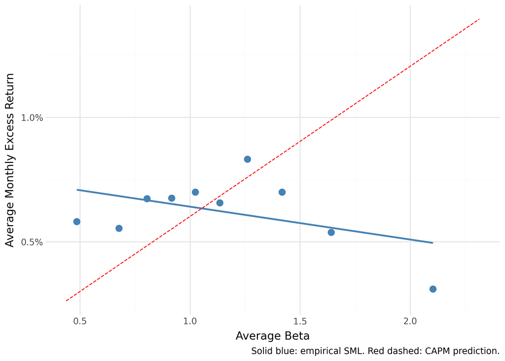

Empirical SML vs CAPM

## Proposition 1: Decile Alpha Results

**Broadly declining alpha across deciles:**

- **Decile 1** $\alpha = +0.27\%$/month
- **Decile 6** : $\alpha \approx 0\%$
- **Decile 10** : $\alpha = -0.82\%$/month, $t = -3.16$

Alpha spread (decile 1 → 10): approximately **−1.1 pp/month**

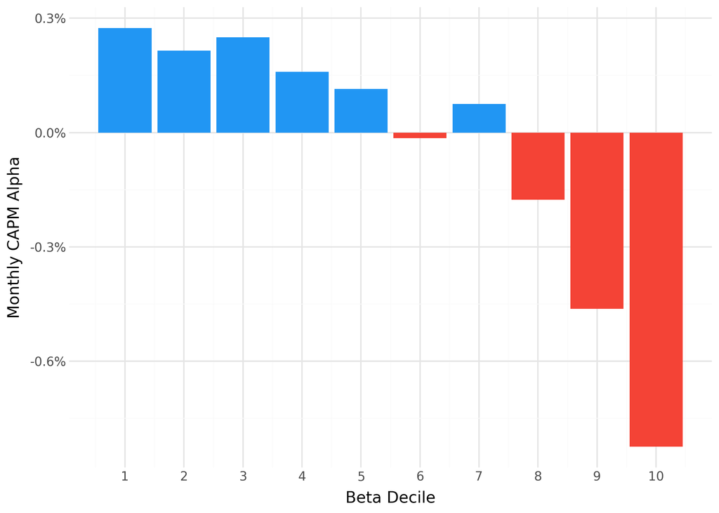

CAPM alpha by beta decile

## Proposition 2: BAB Factor Performance

| Metric | BAB Factor |
| --- | --- |
| Ann. Mean Return | **8.85%** |
| Ann. Std. Deviation | 11.26% |
| Sharpe Ratio | **0.79** |
| *t*-statistic | **6.08** |

Performance statistics for the BAB factor following Frazzini and Pedersen (2014). Mean and SD annualised (×12, ×√12). Sample: US equities, January 1963 – December 2025.

**Sharpe ratio of 0.79** with *t*-stat of **6.08** — strongly statistically significant positive returns. **→ Supports Proposition 2.**

## BAB Cumulative Return

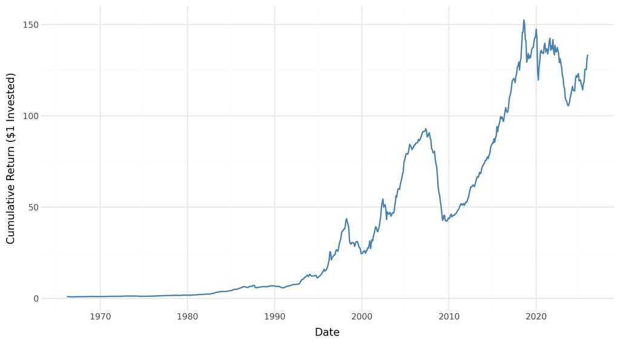

Cumulative BAB return ($1 invested at inception)

**Key observations:**

- Strong growth through the **1990s**
- Partial retrace during **2000–2010**
- Recovery and further compounding toward **2025**

## Transaction Costs

|  | Gross BAB | Net BAB |
| --- | --- | --- |
| Ann. Mean Return | **9.18%** | **−51.12%** |
| *t*-statistic | 3.94 | −13.98 |
| Avg. Annual TC Drag |  | **60.30 pp** |

TC subsample: January 1993 – December 2025 (CRSP bid-ask data unavailable before 1993). Round-trip costs from CRSP daily bid-ask half-spreads, assuming full monthly rebalancing. The gross BAB of 9.18% (TC subsample) and 8.85% (full sample) cover different periods and are **not directly comparable**.

# Discussion

## Proposition 1 in Context

**Consistent with prior literature:**

- Black, Jensen, and Scholes (1972) — first systematic evidence of flat SML (NYSE, 1926–1966)
- Fama and French (1992) — beta loses explanatory power once size & book-to-market included
- Fama and French (2004) — CAPM core prediction contradicted by data

**Our estimates:**

- FMB beta slope: 0.14%/month (*t* = 0.75) — near zero
- Alpha spread (decile 1 to 10): ≈ −1.1 pp/month
- Both economically large and statistically significant at the distribution extremes

## Proposition 2 in Context

- Gross BAB in TC subsample (1993–2025): **9.18%** (*t* = 3.94)
- Full sample (1963–2025): **8.85%** (*t* = 6.08)
- The anomaly appears **persistent** into the more recent period

**Transaction costs are overstated:**

Our TC estimate is an *extreme upper bound*. Frazzini, Israel, and Moskowitz (2015) find costs of in the **tens of basis points**.

## Limitations

**Sample scope:**

- US equities only
- Frazzini and Pedersen (2014) document BAB profitability in **20 international markets** and multiple asset classes

**TC methodology:**

- CRSP quoted spreads are wide
- Full monthly rebalancing → upper bound on turnover

**Construction & bias:**

- High-beta stocks more likely to be small, volatile and distressed
- Delisting return corrections could affect top-decile alpha estimates

# Conclusion

## Key Findings

**Proposition 1**

Strong evidence of a **negative beta–alpha relationship** in US equities (1963–2025).

FMB insignificant and small FMB slope (0.14%/month (t=0.75)).

Alpha spread across deciles: ≈ −1.1 pp/month.

**Proposition 2**

BAB factor earns **8.85% annualised** (SR = 0.79, *t* = 6.08)

**Transaction Costs**

Under full monthly rebalancing with CRSP quoted spreads, TC drag of **60.30 pp/year** renders the net BAB return **−51.12%**.

Frazzini et al (2015), indicate 10 basis point TC

**Future Research**

- Estimation of TC
- Delisting problem
- Sub-period analysis
- International replication

# Questions?

We welcome comments and discussion

**Tobias Dines Schlünssen** · GFS189  
**Conrad Frederik Kromann** · RTL959  
Department of Economics · University of Copenhagen  
Seminar: Asset Prices and Financial Markets · June 2026